### [WWS 586a] Problem Set 4

For these exercises we will be using the Global Terrorism Database (GTD) which can be found on Kaggle: https://www.kaggle.com/START-UMD/gtd/data. The GTD contains a great deal of information about terrorist events and contains roughly 170,000 such events.

### Due Date and Time

Due on Friday, April 27th at 11:59PM

### Guidelines

All problem sets must be submitted as two files:

1. A *R Markdown* file with the following format: “lastname_firstname_ps4.Rmd”. Ie. for me this would be: “anastasopoulos_jason_ps4.Rmd”
2. A compiled *R Markdown* file in HTML with the following format: “lastname_firstname_ps4.html” Ie. for me this would be: “anastasopoulos_jason_ps4.html”

Please only fill in the sections labelled “YOUR CODE HERE”

### Learning about assassinations and bombings through random forests

For this problem set, we will be taking the training wheels off and you will have to use your discretion to train a model using random forests.

The goal of this portion of the assignment is to build a machine learning classifier that will enable you to predict assasination events as a function of the features in the data.

Assasinations are labeled as “1” in the variable “attacktype1” within the GTD and bombings are labeled as “3”. Using whichever features you would like and whichever package you would like, train two random forests classifiers to predict assassinations and bombings using an 80/20 training test split.

Report the: accuracy, specificity, sensitivity and F1 statistics of the classifiers that you trained for each model.

```r
### Code for assasinations classifier
##### YOUR CODE HERE ###################################

library(pacman)

pacman::p_load(tm,SnowballC,foreign,RCurl,plyr,slam,foreign,wordcloud,LiblineaR,e1071,caret,ranger,rpart,rpart.plot)

# localdir = "/Users/xuc/Documents/WWS586a/WWS586A-Machine-Learning-Policy-Analysis
#             /Problem_Sets/Problem-Set-4/"
# setwd(localdir)

# Read data
GTD <- read.csv("globalterrorismdb_0617dist.csv")

# Choose the following 20 features to train my models
cols = c("attacktype1","iyear","imonth","extended","crit1","crit2","crit3","doubtterr","multiple","region","success","suicide","targtype1","weaptype1","individual","natlty1","ishostkid","nkill","nwound","property")

gtd <- GTD[ , cols]
summary(gtd)
```

```
##   attacktype1       iyear          imonth          extended
##  Min.   :1.00   Min.   :1970   Min.   : 0.000   Min.   :0.00000
##  1st Qu.:2.00   1st Qu.:1990   1st Qu.: 4.000   1st Qu.:0.00000
##  Median :3.00   Median :2007   Median : 6.000   Median :0.00000
##  Mean   :3.22   Mean   :2002   Mean   : 6.474   Mean   :0.04363
##  3rd Qu.:3.00   3rd Qu.:2014   3rd Qu.: 9.000   3rd Qu.:0.00000
##  Max.   :9.00   Max.   :2016   Max.   :12.000   Max.   :1.00000
##
##      crit1            crit2           crit3          doubtterr
##  Min.   :0.0000   Min.   :0.000   Min.   :0.0000   Min.   :-9.0000
##  1st Qu.:1.0000   1st Qu.:1.000   1st Qu.:1.0000   1st Qu.: 0.0000
##  Median :1.0000   Median :1.000   Median :1.0000   Median : 0.0000
##  Mean   :0.9884   Mean   :0.993   Mean   :0.8798   Mean   :-0.5721
##  3rd Qu.:1.0000   3rd Qu.:1.000   3rd Qu.:1.0000   3rd Qu.: 0.0000
##  Max.   :1.0000   Max.   :1.000   Max.   :1.0000   Max.   : 1.0000
##
##     multiple          region          success          suicide
##  Min.   :0.0000   Min.   : 1.000   Min.   :0.0000   Min.   :0.00000
##  1st Qu.:0.0000   1st Qu.: 5.000   1st Qu.:1.0000   1st Qu.:0.00000
##  Median :0.0000   Median : 6.000   Median :1.0000   Median :0.00000
##  Mean   :0.1342   Mean   : 7.091   Mean   :0.8964   Mean   :0.03387
##  3rd Qu.:0.0000   3rd Qu.:10.000   3rd Qu.:1.0000   3rd Qu.:0.00000
##  Max.   :1.0000   Max.   :12.000   Max.   :1.0000   Max.   :1.00000
##
##    targtype1      weaptype1        individual          natlty1
##  Min.   : 1.0   Min.   : 1.000   Min.   :0.000000   Min.   :   4.0
##  1st Qu.: 3.0   1st Qu.: 5.000   1st Qu.:0.000000   1st Qu.:  83.0
##  Median : 4.0   Median : 6.000   Median :0.000000   Median : 102.0
##  Mean   : 8.4   Mean   : 6.429   Mean   :0.002483   Mean   : 127.7
##  3rd Qu.:14.0   3rd Qu.: 6.000   3rd Qu.:0.000000   3rd Qu.: 175.0
##  Max.   :22.0   Max.   :13.000   Max.   :1.000000   Max.   :1004.0
##                                                     NA's   :1394
##    ishostkid            nkill              nwound          property
##  Min.   :-9.00000   Min.   :   0.000   Min.   :   0.0   Min.   :-9.000
##  1st Qu.: 0.00000   1st Qu.:   0.000   1st Qu.:   0.0   1st Qu.: 0.000
##  Median : 0.00000   Median :   0.000   Median :   0.0   Median : 1.000
##  Mean   : 0.05918   Mean   :   2.387   Mean   :   3.2   Mean   :-0.506
##  3rd Qu.: 0.00000   3rd Qu.:   2.000   3rd Qu.:   2.0   3rd Qu.: 1.000
##  Max.   : 1.00000   Max.   :1500.000   Max.   :7366.0   Max.   : 1.000
##  NA's   :178        NA's   :9682       NA's   :15325
```

```r
dim(gtd)
```

```
## [1] 170350     20
```

```r
# Delete missing values from data
gtd[gtd==-9] <- NA
gtd = na.omit(gtd)

# Variable "weaptype1" and "targtype1" contains categorical information, expand to dummy variables
# These dummies don't necessarrily imprive performance, but tell more information about, for example, which weapon
# or which region is an important feature

gtd[,"weaptype1"] = as.factor(gtd[,"weaptype1"])
gtd[,"targtype1"] = as.factor(gtd[,"targtype1"])
gtd[,"region"] = as.factor(gtd[,"region"])
gtd = data.frame(model.matrix(~.-1, gtd))

# Now the number of variables have increased due to the inclusion of dummies
dim(gtd)
```

```
## [1] 123095     61
```

```r
View(gtd)

gtd_a <- gtd
gtd_a$attacktype1 = ifelse(gtd$attacktype1==1, 1, 0)

# Train a randorm forest model for assasination
train_id = sample(1:dim(gtd_a)[1], dim(gtd_a)[1]*0.8)
train_a = gtd_a[train_id,]
test_a = gtd_a[-train_id,]

trctrl <- trainControl(method = "repeatedcv", number = 10, repeats = 1)

set.seed(333)

# Because question #2 asks for feature importance evaluated by % increase of MSE,
# here when training the model, I use "permutation" instead of "impurity" as measure of importance.
# Using "impurity" takes much shorter time ...
rf_fit1<-ranger(factor(attacktype1)~., data=train_a,
                                       importance='permutation',
                                       write.forest=TRUE,
                                       probability=TRUE)
```

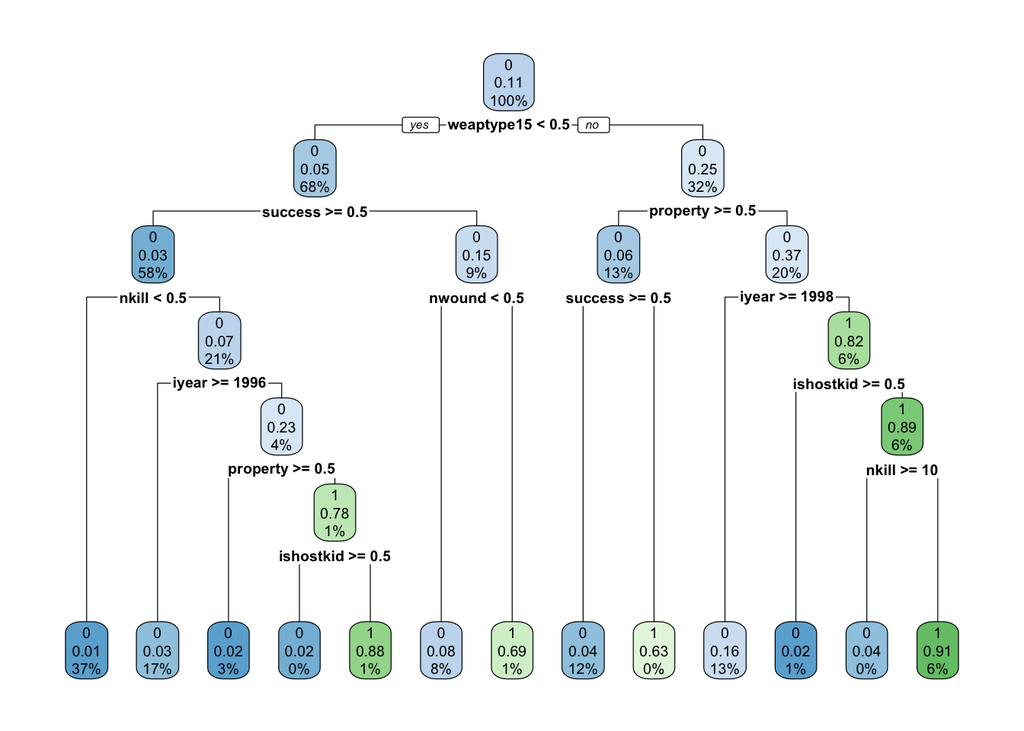

```r
# Visualize decision tree
trees=rpart(factor(attacktype1)~., train_a)
rpart.plot(trees)
```

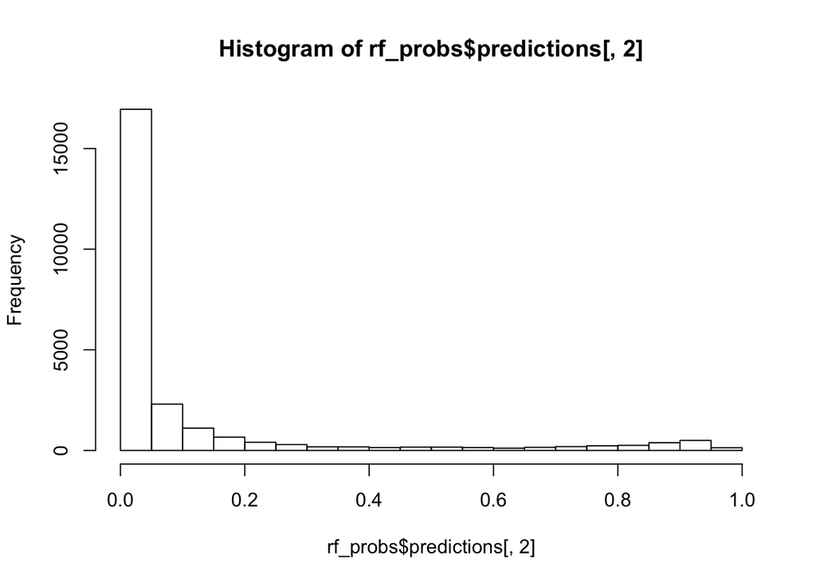

```r
# Predict on test data
rf_probs<-predict(rf_fit1, test_a)

rf_class<-ifelse(rf_probs$predictions[,2] > 0.5, 1, 0)

hist(rf_probs$predictions[,2])
```

```r
# Histogram shows relatively good performance of the model.

# Performance
confusion<-table(rf_class, factor(test_a$attacktype1))
confusion
```

```
##
## rf_class     0     1
##        0 21588   785
##        1   193  2053
```

```r
TP_a = confusion[2,2]
TN_a = confusion[1,1]
FP_a = confusion[2,1]
FN_a = confusion[1,2]

accuracy_a = (TP_a+TN_a)/(TP_a+TN_a+FP_a+FN_a)
specificity_a = TN_a/(TN_a+FP_a)
sensitivity_a = TP_a/(TP_a+FN_a)
f1_a = 2*TP_a/(2*TP_a+FP_a+FN_a)

cat(sprintf("Accuracy: %6.3f \nSpecificity: %6.3f \nSensitivity: %6.3f \nF1 score: %6.3f", accuracy_a, specificity_a, sensitivity_a, f1_a))
```

```
## Accuracy:  0.960
## Specificity:  0.991
## Sensitivity:  0.723
## F1 score:  0.808
```

```r
print("Sensitivity is not as good performance as specificity because in this case, there is a small portion of assisinations in the training data, so type II error is more prevalent. ")
```

```
## [1] "Sensitivity is not as good performance as specificity because in this case, there is a small portion of assisinations in the training data, so type II error is more prevalent. "
```

```r
##### YOUR CODE HERE ###################################
```

```r
### Code for bombings classifier
##### YOUR CODE HERE ###################################

gtd_b <- gtd
gtd_b$attacktype1 = ifelse(gtd$attacktype1==3, 1, 0)

# Train a random forest model for bombings
train_id = sample(1:dim(gtd_b)[1], dim(gtd_b)[1]*0.8)
train_b = gtd_b[train_id,]
test_b = gtd_b[-train_id,]

trctrl <- trainControl(method = "repeatedcv", number = 10, repeats = 1)

set.seed(3333)

rf_fit2<-ranger(factor(attacktype1)~., data=train_b,
                                       importance='permutation',
                                       write.forest=TRUE,
                                       probability=TRUE)
```

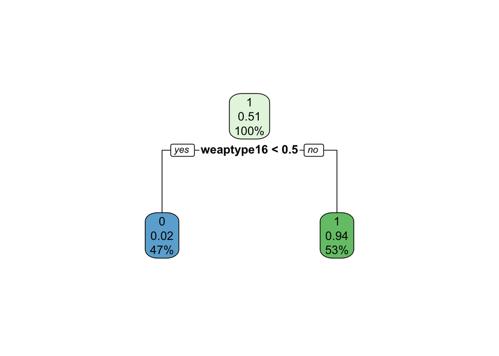

```r
# Visualize the decision tree
trees=rpart(factor(attacktype1)~., train_b)
rpart.plot(trees)
```

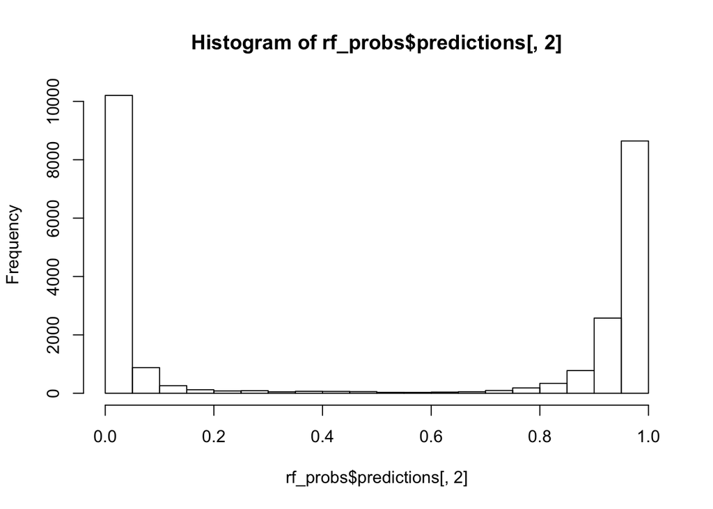

```r
# We see that "weapon type #6" is the single most important feature for bombing classifier.

rf_probs<-predict(rf_fit2, test_b)

rf_class<-ifelse(rf_probs$predictions[,2] > 0.5, 1, 0)

hist(rf_probs$predictions[,2])
```

```r
# The histogram shows that this is a pretty good classifier.

# Performance
confusion<-table(rf_class, factor(test_b$attacktype1))
confusion
```

```
##
## rf_class     0     1
##        0 11596   263
##        1   462 12298
```

```r
TP_b = confusion[2,2]
TN_b = confusion[1,1]
FP_b = confusion[2,1]
FN_b = confusion[1,2]

accuracy_b = (TP_b+TN_b)/(TP_b+TN_b+FP_b+FN_b)
specificity_b = TN_b/(TN_b+FP_b)
sensitivity_b = TP_b/(TP_b+FN_b)
f1_b = 2*TP_b/(2*TP_b+FP_b+FN_b)

cat(sprintf("Accuracy: %6.3f \nSpecificity: %6.3f \nSensitivity: %6.3f \nF1 score: %6.3f", accuracy_b, specificity_b, sensitivity_b, f1_b))
```

```
## Accuracy:  0.971
## Specificity:  0.962
## Sensitivity:  0.979
## F1 score:  0.971
```

```r
##### YOUR CODE HERE ###################################
```

### 2. Which features predict assasinations and bombings best?

One of the best things about the random forests algorithm is that it allows us to understand which features contributed most to prediction success.

Create a plot of the top 10 most important features for each classifier using the % increase in MSE estimate to determine feature importance.

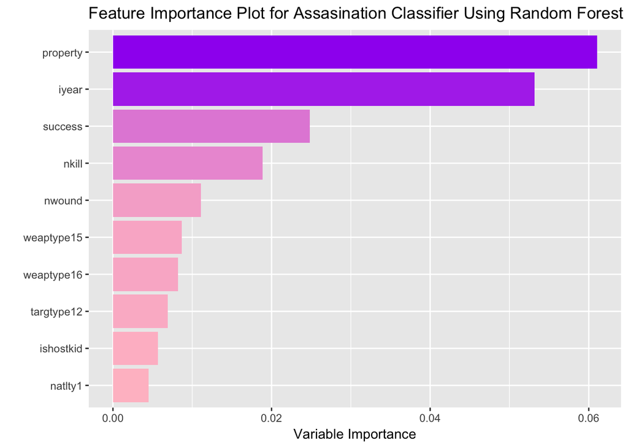

```r
### Plot for assasinations classifier
##### YOUR CODE HERE ###################################

varimp_a = rf_fit1$variable.importance

features<-names(varimp_a)
importance<-as.vector(varimp_a)
importance.data = data.frame(features,importance)

# Rank the importance of the features
importance.data = importance.data[order(-importance.data$importance),]
importance.data = importance.data[1:10,]

# Now we can use ggplot2 to create the plot
# Plot variable importance
ggplot(importance.data,
       aes(x=reorder(features,importance), y=importance,fill=importance))+
       geom_bar(stat="identity", position="dodge")+ coord_flip()+
       ylab("Variable Importance")+
       xlab("")+
       ggtitle("Feature Importance Plot for Assasination Classifier Using Random Forest")+
       guides(fill=F)+
       scale_fill_gradient(low="pink", high="purple")
```

```r
##### YOUR CODE HERE ###################################
```

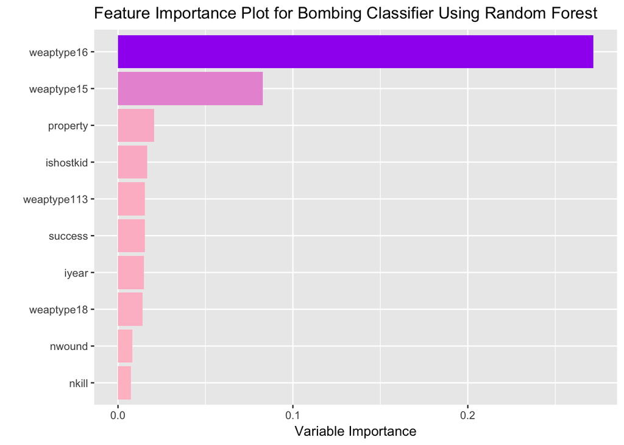

```r
### Plot for bombings classifier
##### YOUR CODE HERE ###################################

varimp_b = rf_fit2$variable.importance

features<-names(varimp_b)
importance<-as.vector(varimp_b)
importance.data = data.frame(features,importance)

importance.data = importance.data[order(-importance.data$importance),]
importance.data = importance.data[1:10,]

# Now we can use ggplot2 to create the plot
# Plot variable importance
ggplot(importance.data,
       aes(x=reorder(features,importance), y=importance,fill=importance))+
       geom_bar(stat="identity", position="dodge")+ coord_flip()+
       ylab("Variable Importance")+
       xlab("")+
       ggtitle("Feature Importance Plot for Bombing Classifier Using Random Forest")+
       guides(fill=F)+
       scale_fill_gradient(low="pink", high="purple")
```

```r
##### YOUR CODE HERE ###################################
```

### 3. Lasso classification of assasinations and bombings

Using logistic regression with $L_1$ regularization (logistic regression lasso), train a model with the same features that you used for your decision tree classifiers above using an 80/20 train/test split.

Report the accuracy, specificity, sensistivity and F1 statistics for the trained logistic regression classifier for assasinations and bombings

```r
### Code for assasinations classifier
##### YOUR CODE HERE ###################################

require(glmnet)
```

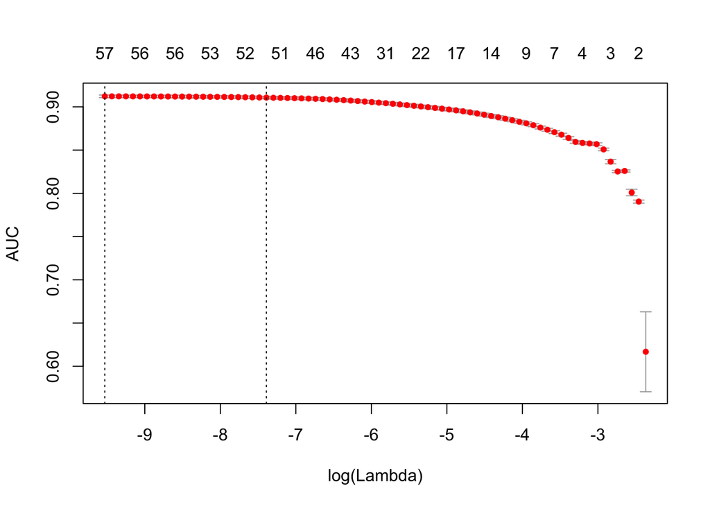

```r
x_train = as.matrix(train_a[,-1])
x_test = as.matrix(test_a[,-1])

# Train a Lasso classifier for assasinations
cv.lasso1 <- cv.glmnet(x=x_train, y=as.factor(train_a[,1]), family='binomial', alpha=1,
                       standardize=TRUE, type.measure='auc')
plot(cv.lasso1)
```

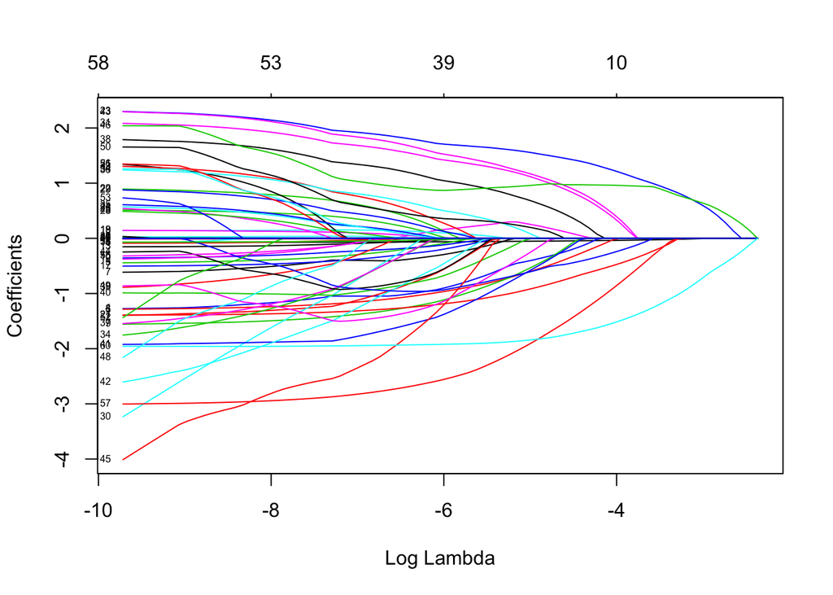

```r
plot(cv.lasso1$glmnet.fit, xvar="lambda", label=TRUE)
```

```r
cv.lasso1$lambda.min
```

```
## [1] 7.264934e-05
```

```r
cv.lasso1$lambda.1se
```

```
## [1] 0.0006173403
```

```r
# Print coefficients
coef(cv.lasso1, s=cv.lasso1$lambda.min)
```

```
## 61 x 1 sparse Matrix of class "dgCMatrix"
##                         1
## (Intercept)  1.451901e+02
## iyear       -7.278926e-02
## imonth      -1.089302e-02
## extended    -4.402378e-01
## crit1       -1.270384e+00
## crit2       -7.862521e-02
## crit3        1.425171e-02
## doubtterr   -6.107464e-01
## multiple    -1.282288e+00
## region1     -1.552470e+00
## region2     -3.532281e-01
## region3      2.599588e-02
## region4     -3.705391e-01
## region5     -1.523589e-01
## region6     -8.808465e-02
## region7      5.102191e-01
## region8      .
## region9     -5.022492e-01
## region10     1.404830e-01
## region11     1.428871e-01
## region12     .
## success     -1.391699e+00
## suicide      8.878320e-01
## targtype12   2.290154e+00
## targtype13   5.642904e-01
## targtype14   5.252329e-01
## targtype15   1.317542e+00
## targtype16  -1.388320e+00
## targtype17   4.798356e-01
## targtype18   8.681111e-01
## targtype19  -3.054003e+00
## targtype110  2.075275e+00
## targtype111  1.838537e-02
## targtype112  1.293625e+00
## targtype113 -1.724482e+00
## targtype114  6.009771e-01
## targtype115  1.230014e+00
## targtype116 -1.524935e+00
```

[output cut: 8 more lines]

```
## weaptype15   2.039978e+00
## weaptype16   .
## weaptype17  -1.972690e+00
## weaptype18  -8.571010e-01
## weaptype19   1.652942e+00
## weaptype110  1.339702e+00
## weaptype111 -1.245894e+00
## weaptype112  7.101546e-01
## weaptype113  1.256635e+00
## individual  -3.140136e-01
## natlty1     -2.704079e-04
## ishostkid   -3.000027e+00
## nkill       -6.825540e-02
## nwound      -6.039156e-03
## property    -1.956766e+00
```

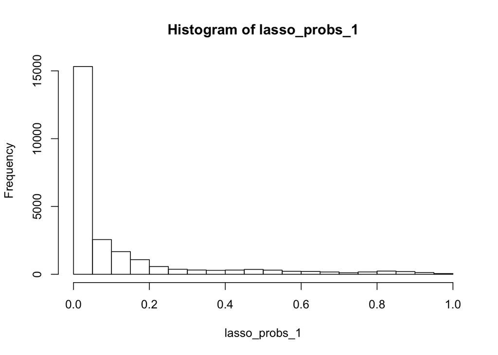

```r
# Predict using test data
lasso_probs_1<-predict(cv.lasso1, x_test, type="response")

lasso_class_1<-ifelse(lasso_probs_1 > 0.5, 1, 0)
hist(lasso_probs_1)
```

```r
# Performance
confusion<-table(lasso_class_1, factor(test_a$attacktype1))
confusion
```

```
##
## lasso_class_1     0     1
##             0 21355  1479
##             1   426  1359
```

```r
TP = confusion[2,2]
TN = confusion[1,1]
FP = confusion[2,1]
FN = confusion[1,2]

accuracy_a = (TP+TN)/(TP+TN+FP+FN)
specificity_a = TN/(TN+FP)
sensitivity_a = TP/(TP+FN)
f1_a = 2*TP/(2*TP+FP+FN)

cat(sprintf("Accuracy: %6.3f \nSpecificity: %6.3f \nSensitivity: %6.3f \nF1 score: %6.3f", accuracy_a, specificity_a, sensitivity_a, f1_a))
```

```
## Accuracy:  0.923
## Specificity:  0.980
## Sensitivity:  0.479
## F1 score:  0.588
```

```r
##### YOUR CODE HERE ###################################
```

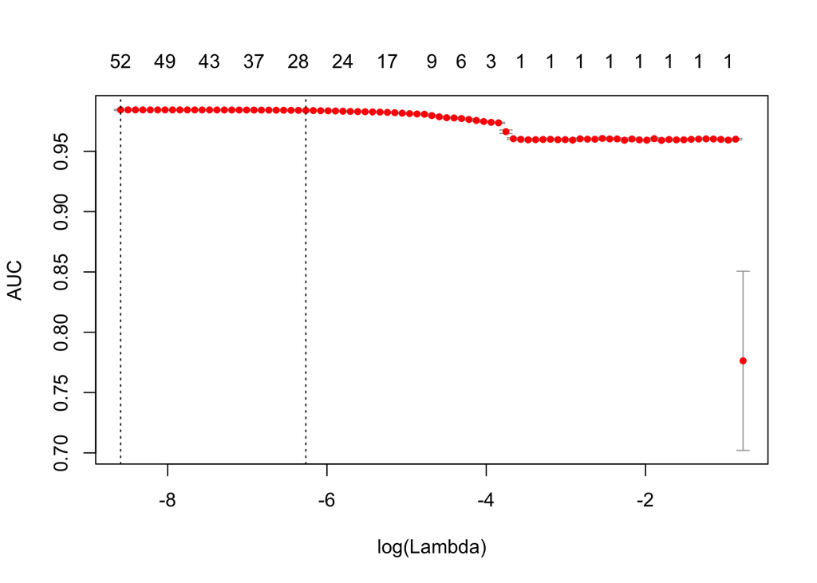

```r
### Code for bombings classifier
##### YOUR CODE HERE ###################################

x_train_b = as.matrix(train_b[,-1])
x_test_b = as.matrix(test_b[,-1])

# Train a Lasso classifier for bombings
cv.lasso2 <- cv.glmnet(x=x_train_b, y=as.factor(train_b[,1]), family='binomial', alpha=1,
                       standardize=TRUE, type.measure='auc')
plot(cv.lasso2)
```

```r
coef(cv.lasso2, s=cv.lasso2$lambda.min)
```

```
## 61 x 1 sparse Matrix of class "dgCMatrix"
##                        1
## (Intercept) 35.914562475
## iyear       -0.020992644
## imonth      -0.003145048
## extended    -0.119567353
## crit1        0.220837562
## crit2        0.050742481
## crit3        0.569204212
## doubtterr    .
## multiple     0.374533430
## region1      0.162715417
## region2     -0.072883026
## region3      0.069892524
## region4      0.454943764
## region5      .
## region6     -0.031807716
## region7     -0.395920396
## region8      0.334309295
## region9     -0.366110899
## region10     0.067990039
## region11    -0.811848258
## region12    -0.132596580
## success      1.620345398
## suicide      0.622742830
## targtype12  -1.564528362
## targtype13  -1.011348179
## targtype14  -0.458048119
## targtype15  -0.206905561
## targtype16  -0.230445164
## targtype17  -0.393878439
## targtype18   0.030740360
## targtype19   0.987287392
## targtype110 -1.255015853
## targtype111  0.615894622
## targtype112 -0.946231265
## targtype113  .
## targtype114 -0.115989242
## targtype115  .
## targtype116  0.544442125
```

[output cut: 8 more lines]

```
## weaptype15   .
## weaptype16   7.310024117
## weaptype17   4.343080224
## weaptype18  -0.442142963
## weaptype19  -1.858253868
## weaptype110  0.216582167
## weaptype111 -1.443040977
## weaptype112  .
## weaptype113  0.878426016
## individual   .
## natlty1     -0.000304622
## ishostkid   -4.396333831
## nkill       -0.012286403
## nwound       0.000017430
## property     0.412892092
```

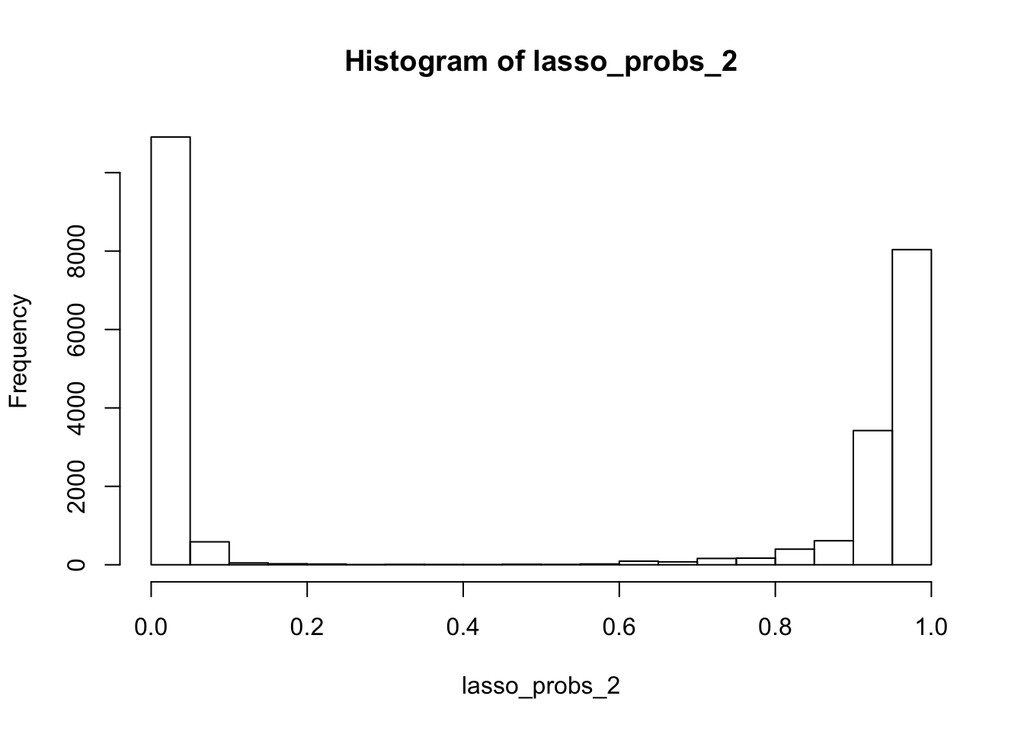

```r
# Predict using test data
# Histogram of predictions
lasso_probs_2<-predict(cv.lasso2, x_test_b, type="response")
hist(lasso_probs_2)
```

```r
lasso_class_2<-ifelse(lasso_probs_2 > 0.5, 1, 0)

# Performance
confusion<-table(lasso_class_2, factor(test_b$attacktype1))
confusion
```

```
##
## lasso_class_2     0     1
##             0 11355   270
##             1   703 12291
```

```r
TP = confusion[2,2]
TN = confusion[1,1]
FP = confusion[2,1]
FN = confusion[1,2]

accuracy_b = (TP+TN)/(TP+TN+FP+FN)
specificity_b = TN/(TN+FP)
sensitivity_b = TP/(TP+FN)
f1_b = 2*TP/(2*TP+FP+FN)

cat(sprintf("Accuracy: %6.3f \nSpecificity: %6.3f \nSensitivity: %6.3f \nF1 score: %6.3f", accuracy_b, specificity_b, sensitivity_b, f1_b))
```

```
## Accuracy:  0.960
## Specificity:  0.942
## Sensitivity:  0.979
## F1 score:  0.962
```

```r
##### YOUR CODE HERE ###################################
```

### 4. Features predicting bombings and assisnations best using the lasso.

Create a plot of the top 10 most important features for each classifier using the coefficient estimates from the lasso model. As long as you standardized your data when you estimated the lasso model, the coefficient estimates will be on the same scale.

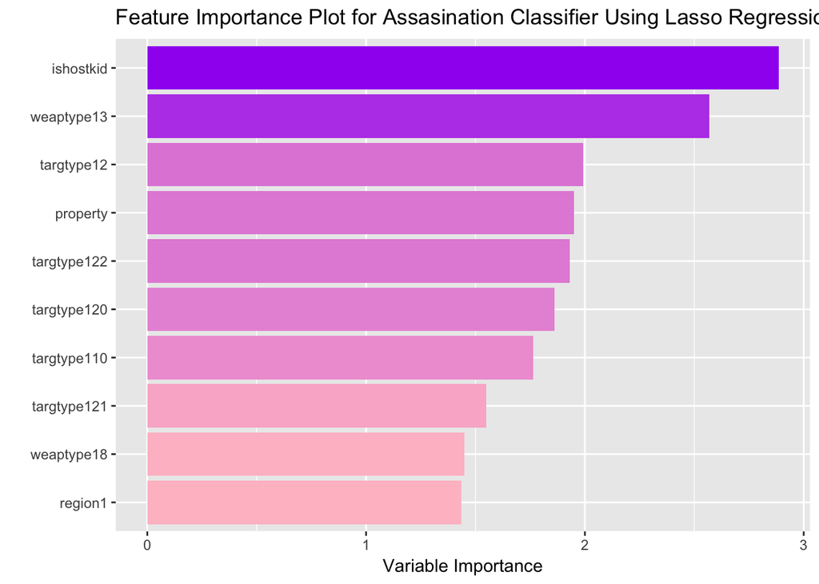

```r
### Plot for assasinations classifier
##### YOUR CODE HERE ###################################

features<-names(train_a[-1])
importance<-as.vector(abs(coef(cv.lasso1)[-1]))

importance.data = data.frame(features,importance)

# Reorder the data frame in descending order
importance.data = importance.data[order(-importance.data$importance),]
importance.data = importance.data[1:10,]

# Now we can use ggplot2 to create the plot
# Plot variable importance
ggplot(importance.data,
       aes(x=reorder(features,importance), y=importance,fill=importance))+
       geom_bar(stat="identity", position="dodge")+ coord_flip()+
       ylab("Variable Importance")+
       xlab("")+
       ggtitle("Feature Importance Plot for Assasination Classifier Using Lasso Regression")+
       guides(fill=F)+
       scale_fill_gradient(low="pink", high="purple")
```

```r
##### YOUR CODE HERE ###################################
```

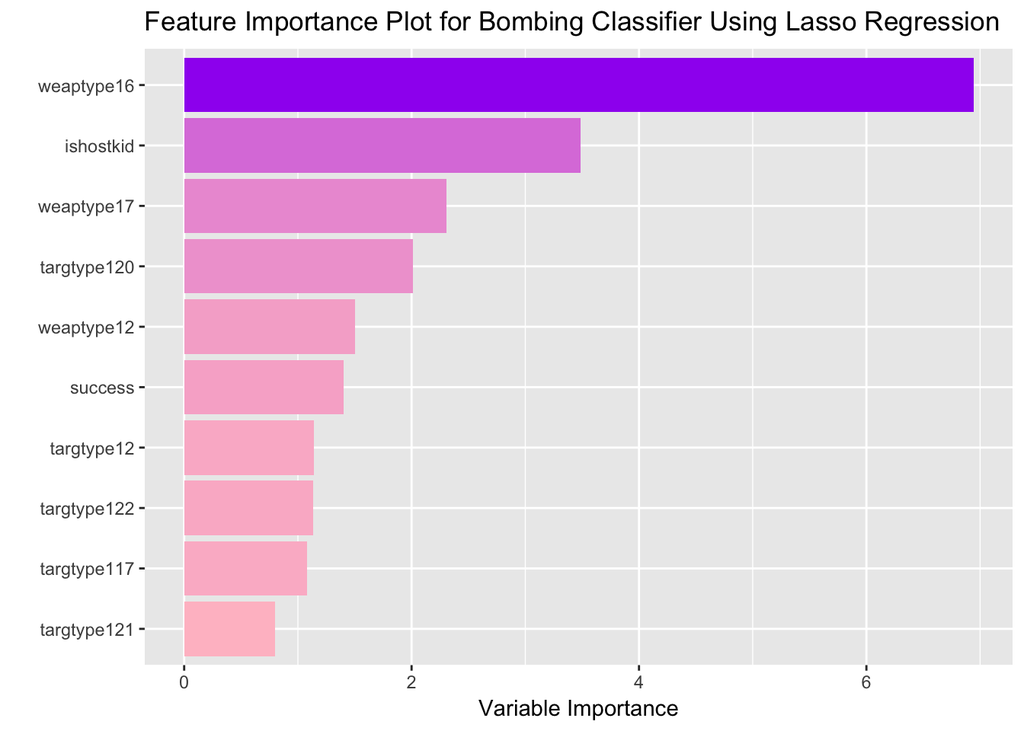

```r
### Plot for bombings classifier
##### YOUR CODE HERE ###################################

features<-names(train_b[-1])
importance<-as.vector(abs(coef(cv.lasso2)[-1]))

importance.data = data.frame(features,importance)

# Reorder the data frame in descending order
importance.data = importance.data[order(-importance.data$importance),]
importance.data = importance.data[1:10,]

# Now we can use ggplot2 to create the plot
# Plot variable importance
ggplot(importance.data,
       aes(x=reorder(features,importance), y=importance,fill=importance))+
       geom_bar(stat="identity", position="dodge")+ coord_flip()+
       ylab("Variable Importance")+
       xlab("")+
       ggtitle("Feature Importance Plot for Bombing Classifier Using Lasso Regression")+
       guides(fill=F)+
       scale_fill_gradient(low="pink", high="purple")
```

```r
##### YOUR CODE HERE ###################################
```